# Assignment2

Cheng

3/16/2019

```r
#import library
library(rethinking)
library(tidyverse)
library(tidybayes)
library(rstan)
library(ggplot2)
library(ggthemes)
```

# 1 Question1

By using the Howell1 data mentioned in the class, the weights listed below were recorded in the !Kung census, but heights were not recorded for these individuals. Provide predicted heights and 89% intervals (either HPDI or PI) for each of these individuals. That is, fill in the table below, using model-based predictions. (Hint:library(rethinking);data(Howell1))

```r
#import the data
data(Howell1)
d <- Howell1
```

Before modeling, let’s take a look of `height` data

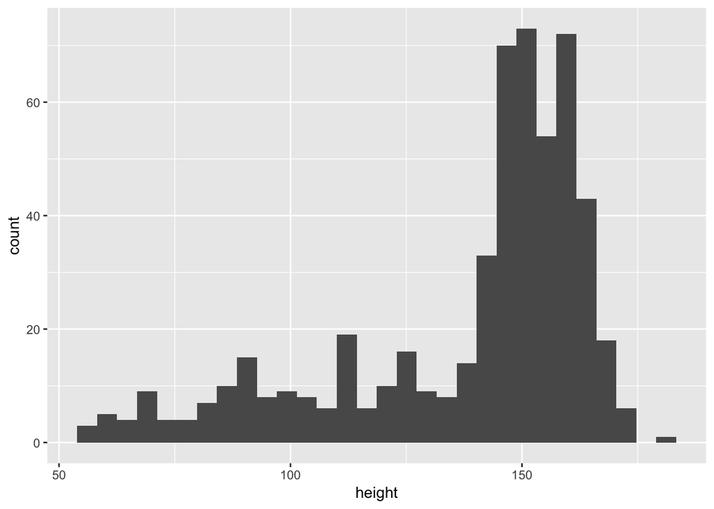

```r
d %>%
  ggplot() +
  geom_histogram(aes(height))
```

```r
# create Rstan model
m01 <- "
  data {
    int<lower=1> N;
    int<lower=1> N2;
    vector[N] height;
    vector[N] weight;
    vector[N2] weight_test;
  }
  parameters {
    real alpha;
    real beta;
    real<lower=0,upper=50> sigma;
  }
  model {
    vector[N] mu = alpha + beta * weight;

    // prior
    alpha ~ normal(178, 20);
    beta ~ lognormal(0,1);

    //likelihood
    height ~ normal(mu, sigma);
  }
  generated quantities{
    real pred_y[N2];
    vector[N2] mu = alpha + beta * weight_test;

    pred_y = normal_rng(mu, sigma);
  }

"

weight_test = c(46.95, 43.72, 64.78, 32.59, 54.63)

dat <- list(N = NROW(d),
            height = d$height,
            weight = d$weight,
            N2 = length(weight_test),
            weight_test = weight_test)

fit01 <- stan(model_code = m01, data = dat, cores = 2, chains = 2, iter = 1000)
fit01.post = as.data.frame(fit01)
```

Prediction Interval

```r
# table
pred_y = fit01.post %>%
  select(contains("pred_y"))

answer.sheet = data.frame(
  individual = seq(1:5),
  weight = weight_test,
  `expected height` = pred_y %>% apply(., 2, mean), # by column
  L_HPDI = pred_y %>% apply(.,2,HPDI) %>% .[1,],
  H_HPDI = pred_y %>% apply(.,2,HPDI) %>% .[2,])

answer.sheet
```

[output not shown]

# 2 Question 2

Select out all the rows in the Howell1 data with ages below 18 years of age. If you do it right, you should end up with a new data frame with 192 rows in it.

```r
d2 <- Howell1[Howell1$age < 18, ]
nrow(d2)
```

[output not shown]

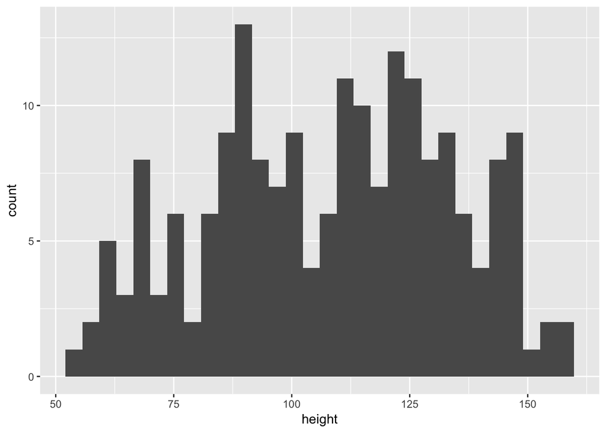

```r
d2 %>%
  ggplot() +
  geom_histogram(aes(height))
```

## 2.1 (a)

Fit a linear regression to these data, using stan model. Present and interpret the estimates. For every 10 units of increase in weight, how much taller does the model predict a child gets?

```r
m02 <- "
data {
int<lower=1> N;
vector[N] height;
vector[N] weight;
}
parameters {
real alpha;
real beta;
real<lower=0,upper=60> sigma;
}
model {
vector[N] mu = alpha + beta * weight;

height ~ normal(mu, sigma);
alpha ~ normal(178, 20);
beta ~ lognormal(0,1);

}
"

# reorganize d data
dat <- list(N = NROW(d2),
            height = d2$height,
            weight = d2$weight)
#sampling
fit02 <- stan(model_code = m02, data = dat, cores = 2, chains = 2, iter = 1000)

# summarize
print(fit02)
```

[output not shown]

## 2.2 (b)

Plot the raw data, with height on the vertical axis and weight on the horizontal axis. Superimpose the stan predicted regression line and 89% HPDI for the mean. Also superimpose the 89% HPDI for predicted heights.

Add generated quantities for predcition and backtesting

```r
m02.1 <- "
  data {
    int<lower=1> N;
    vector[N] height;
    vector[N] weight;
  }
  parameters {
    real alpha;
    real beta;
    real<lower=0,upper=60> sigma;
  }
  model {
    vector[N] mu = alpha + beta * weight;

    height ~ normal(mu, sigma);
    alpha ~ normal(178, 20);
    beta ~ lognormal(0, 1);
  }
  generated quantities {
    real y_pred[N];
    vector[N] mu;

    mu = alpha + beta * weight;
    y_pred = normal_rng(mu, sigma);
  }
"

# reorganize d data
dat <- list(N = NROW(d2),
            height = d2$height,
            weight = d2$weight)
#sampling
fit02.1 <- stan(model_code = m02.1, data = dat, cores = 2, chains = 2, iter = 1000)
post.fit02.1 = as.data.frame(fit02.1)
```

Plot 89% CI The interval for **mean** prediction on each weight.

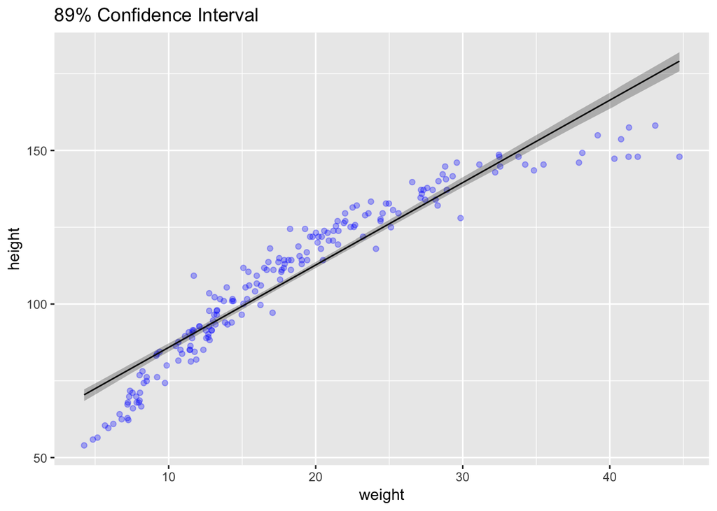

```r
pred_mu = post.fit02.1 %>%
  select(contains("mu"))

CI = data.frame(
  mean = pred_mu %>% apply(., 2, mean),
  L_HPDI = pred_mu %>% apply(.,2,HPDI) %>% .[1,],
  H_HPDI = pred_mu %>% apply(.,2,HPDI) %>% .[2,],
  weight = d2$weight)

CI %>%
  ggplot() +
  geom_point(data = d2, aes(weight, height), color="blue", alpha=.3) +
  geom_line(aes(weight, mean)) +
  geom_ribbon(aes(x=weight,ymin=L_HPDI, ymax=H_HPDI), alpha=.3) +
  ggtitle("89% Confidence Interval")
```

Plot 89% Pridiction interval The interval for **one** prediction on each weight.

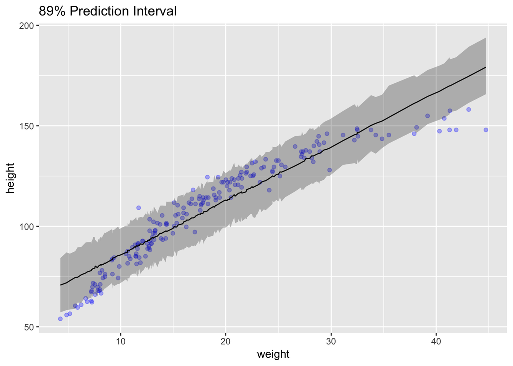

```r
pred_y = post.fit02.1 %>%
  select(contains("y_pred"))

PI = data.frame(
  mean = pred_y %>% apply(., 2, mean),
  L_HPDI = pred_y %>% apply(.,2,HPDI) %>% .[1,],
  H_HPDI = pred_y %>% apply(.,2,HPDI) %>% .[2,],
  weight = d2$weight)

PI %>%
  ggplot() +
  geom_point(data = d2, aes(weight, height), color="blue", alpha=.3) +
  geom_line(aes(weight, mean)) +
  geom_ribbon(aes(x=weight,ymin=L_HPDI, ymax=H_HPDI), alpha=.3) +
  ggtitle("89% Prediction Interval")
```

Plot CI & PI together

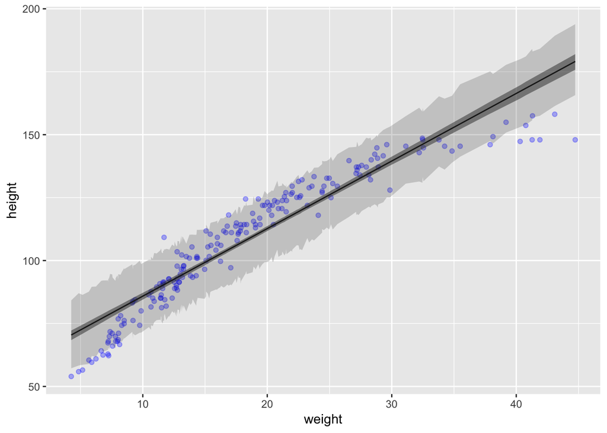

```r
ggplot()+
  geom_point(data = d2, aes(weight, height), color="blue", alpha=.3) +
  geom_line(data=CI, aes(weight, mean)) +
  geom_ribbon(data=CI, aes(x=weight, ymin=L_HPDI, ymax=H_HPDI), alpha=.5) +
  geom_ribbon(data=PI, aes(x=weight,ymin=L_HPDI, ymax=H_HPDI), alpha=.2)
```

## 2.3 (c)

What aspects of the model fit concern you? Describe the kinds of assumption you would change, if any, to improve your model. You don’t have to write any new code. Just explain what the model appears to be doing a bad job of, and what you hypothesize would be a better model?

The linear model seems not perform well.The assumption that the relationship between μ and weight is linear may be wrong. I think I’ll try polynomial regression next.

# 3 Question 3

Suppose a colleague of yours, who works on allometry, glances at the practice problems just above. (In Question 2). You colleague exclaims, “That’s silly. Everyone knows that it’s only the logarithm of body weight that scales with height!” Let’s take your colleague’s advice and see what happens.

$h_{i}$ ~ Normal($μ_{i}$, $\sigma$) $μ_{i}$ = $\alpha$ + $\beta$ log($w_{i}$) $\alpha$ ~ Normal(178, 100) $\beta$ ~ Normal(0, 100) $\sigma$ ~ Uniform(0, 50)

## 3.1 (a)

Model the relationship between height (cm) and the natural logarithm of weight (log-kg). Use the entire Howell1 data frame, all 544 rows, adults and non-adults.Fit this model, using MCMC (stan):

```r
d <- Howell1
d$weight_log = log(d$weight)
```

```r
m03 <- "
  data {
    int<lower=1> N;
    vector[N] height;
    vector[N] weight_log;
  }
  parameters {
    real alpha;
    real beta;
    real<lower=0,upper=50> sigma;
  }
  model {
    vector[N] mu = alpha + beta * weight_log;

    height ~ normal(mu, sigma);
    alpha ~ normal(178,100);
    beta ~ normal(0,100);
  }
  generated quantities {
    real y_pred[N];
    vector[N] mu;

    mu = alpha + beta * weight_log;
    y_pred = normal_rng(mu, sigma);
  }
"

# reorganize d data
dat <- list(N = NROW(d),
            height = d$height,
            weight_log = d$weight_log)
#sampling
fit03 <- stan(model_code = m03, data = dat, cores = 2, chains = 2, iter = 1000)
post.fit03 = as.data.frame(fit03)

# summarize
summary(fit03, pars=c("alpha","beta", "sigma"))[[1]] %>%
  as.data.frame() %>%
  select(mean, sd)
```

[output not shown]

## 3.2 (b)

Begin with this plot: `plot(height~weight, data=Howell1, col=col.alpha(rangi2, 0.4))` Then use samples from the approximate posterior of the model in (a) to superimpose on the plot: (1) the predicted mean height as a function of weight, (2) the 97% HPDI for the mean, and (3) the 97% HPDI for predicted heights.

Plot raw data

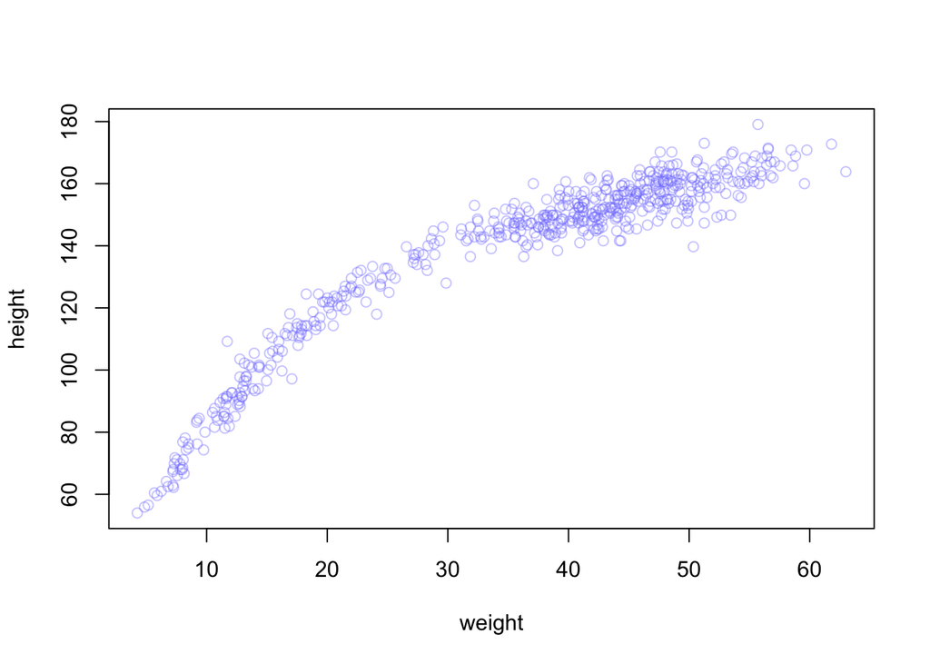

```r
plot(height~weight, data=Howell1, col=col.alpha(rangi2, 0.4))
```

1. Plot the predicted mean height as a function of weight

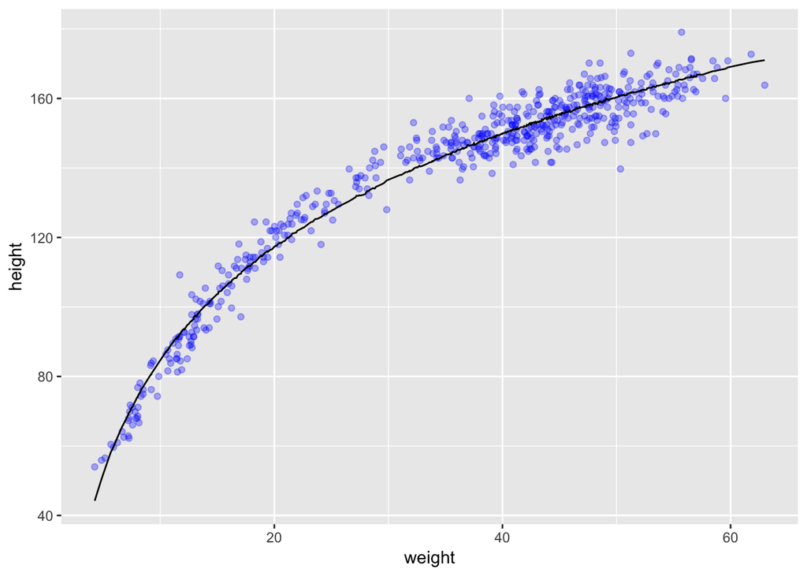

```r
pred_y = post.fit03 %>%
  select(contains("y_pred"))

pred_y = data.frame(
  mean = pred_y %>% apply(., 2, mean),
  weight = d$weight)

pred_y %>%
  ggplot() +
  geom_point(data = d, aes(weight, height), color="blue", alpha=.3) +
  geom_line(aes(weight, mean))
```

2. Plot the 97% HPDI for the mean

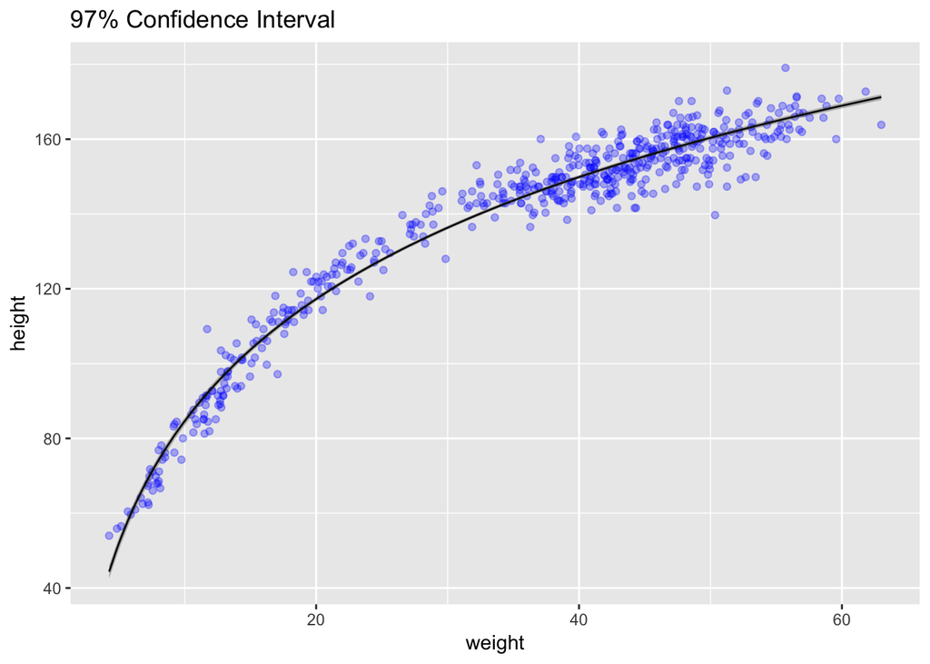

```r
pred_mu = post.fit03 %>%
  select(contains("mu"))

CI = data.frame(
  mean = pred_mu %>% apply(., 2, mean),
  L_HPDI = pred_mu %>% apply(., 2, HPDI, prob = 0.97) %>% .[1,],
  H_HPDI = pred_mu %>% apply(., 2, HPDI, prob = 0.97) %>% .[2,],
  weight = d$weight)

CI %>%
  ggplot() +
  geom_point(data = d, aes(weight, height), color="blue", alpha=.3) +
  geom_line(aes(weight, mean)) +
  geom_ribbon(aes(x=weight,ymin=L_HPDI, ymax=H_HPDI), alpha=.3) +
  ggtitle("97% Confidence Interval")
```

3. Plot the 97% HPDI for predicted heights.

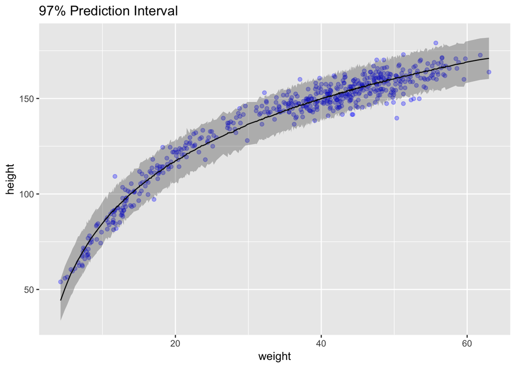

```r
pred_y = post.fit03 %>%
  select(contains("y_pred"))

PI = data.frame(
  mean = pred_y %>% apply(., 2, mean),
  L_HPDI = pred_y %>% apply(.,2,HPDI, prob = 0.97) %>% .[1,],
  H_HPDI = pred_y %>% apply(.,2,HPDI, prob = 0.97) %>% .[2,],
  weight = d$weight)

PI %>%
  ggplot() +
  geom_point(data = d, aes(weight, height), color="blue", alpha=.3) +
  geom_line(aes(weight, mean)) +
  geom_ribbon(aes(x=weight,ymin=L_HPDI, ymax=H_HPDI), alpha=.3) +
  ggtitle("97% Prediction Interval")
```

Plot CI & PI together

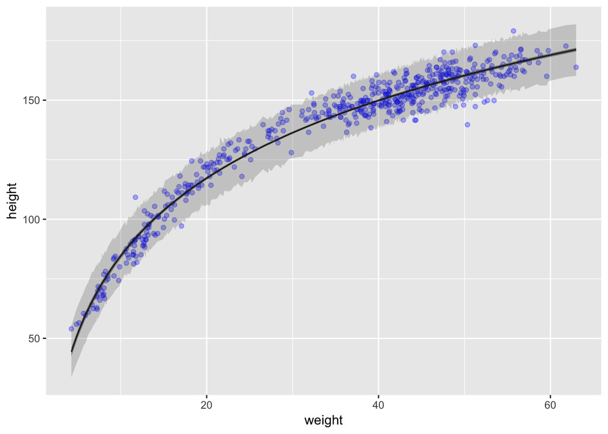

```r
ggplot()+
  geom_point(data = d, aes(weight, height), color="blue", alpha=.3) +
  geom_line(data=CI, aes(weight, mean)) +
  geom_ribbon(data=CI, aes(x=weight, ymin=L_HPDI, ymax=H_HPDI), alpha=.5) +
  geom_ribbon(data=PI, aes(x=weight,ymin=L_HPDI, ymax=H_HPDI), alpha=.2)
```